# Tidy Text, Tokens, and Twitter

Text Mining Learning Lab 1

June 21, 2021

## 1. PREPARE

The transition to digital learning has made available new sources of data, providing researchers new opportunities for understanding and improving STEM learning. Data sources such as digital learning environments and administrative data systems, as well as data produced by social media websites and the mass digitization of academic and practitioner publications, hold enormous potential to address a range of pressing problems in STEM Education, but collecting and analyzing text-based data also presents unique challenges.

**Text Mining (TM) Module 1: Public Sentiment and the State Standards** will help demonstrate how text mining can be applied in STEM education research and provide LASER Institute scholars hands-on experience with popular techniques for collecting, processing, and analyzing text-based data. Specifically, the three learning labs that make up this module address the following topics:

- **Learning Lab 1: Tidy Text, Tokens, & Twitter.** We take a closer look at the literature guiding our analysis; wrangle our data into a one-token-per-row tidy text format; and use simple word counts to explore our tweets about the common core and next generation science standards.
- **Learning Lab 2: Come to the Dark Side.** We focus on the use of lexicons in our third lab and introduce the {vader} package to compare the sentiment of tweets about the NGSS and CCSS state standards in order to better understand public reaction to these two curriculum reform efforts.
- **Learning Lab 3: A Tale of Two Standards.** We wrap our look at public sentiment around STEM state curriculum standards by selecting an analysis that provides some unique insight; refining and polishing a data product; and writing a brief narrative to communicate findings in response to our research questions.
- **Learning Lab 4: rTweet & the Twitter API (Optional).** This supplemental learning lab will get you up and running with the Twitter API in case you are interested in using data from Twitter in your own research. This lab can only be completed by those who created a Twitter Developer account.

### 1a. Review the Literature

Text Mining Module 1 is guided by a recent publication by (J. M. Rosenberg et al., 2021) *Understanding Public Sentiment About Educational Reforms: The Next Generation Science Standards on Twitter*. This study in turn builds on upon previous work by Wang & Fikis (2017) examining public opinion on the Common Core State Standards (CCSS) on Twitter. For Module 1, we will focus on analyzing tweets about the [Next Generation Science Standards](https://www.nextgenscience.org) (NGSS) and [Common Core State Standards](http://www.corestandards.org) (CCSS) in order to better understand key words and phrases that emerge, as well as public sentiment towards these two curriculum reform efforts.

#### Twitter and the Next Generation Science Standards

[figure not shown]

[Full Paper (AERA Open)](https://journals.sagepub.com/doi/full/10.1177/23328584211024261)

##### Abstract

System-wide educational reforms are difficult to implement in the United States, but despite the difficulties, reforms can be successful, particularly when they are associated with broad public support. This study reports on the nature of the public sentiment expressed about a nationwide science education reform effort, the Next Generation Science Standards (NGSS). Through the use of data science techniques to measure the sentiment of posts on Twitter about the NGSS (*N* = 565,283), we found that public sentiment about the NGSS is positive, with only 11 negative posts for every 100 positive posts. In contrast to findings from past research and public opinion polling on the Common Core State Standards, sentiment about the NGSS has become more positive over time—and was especially positive for teachers. We discuss what this positive sentiment may indicate about the success of the NGSS in light of opposition to the Common Core State Standards.

##### Data Sources

Similar to what we’ll be learning in this lab, Rosenberg et al. used publicly accessible data from Twitter collected using the Full-Archive Twitter API and the `rtweet` package in R. Specifically, the authors accessed tweets and user information from the hashtag-based #NGSSchat online community, all tweets that included any of the following phrases, with “/” indicating an additional phrase featuring the respective plural form: “ngss,” “next generation science standard/s,” “next gen science standard/s.”

Data used in this lab was pulled using an [Academic Research developer account](https://developer.twitter.com/en/products/twitter-api/academic-research) and the {academictwitter} package, which uses the Twitter API v2 endpoints and allows researchers to access the full twitter archive. For those that created a standard developer account, the [rtweet & the Twitter API](https://laser-institute.github.io/text-mining/tm-learning-lab-1a.html) supplemental learning lab will show you how to pull your own data from Twitter.

```r
library(academictwitteR)
library(tidyverse)

ccss_tweets_2021 <-
  get_all_tweets('(#commoncore OR "common core") -is:retweet lang:en',
                 "2021-01-01T00:00:00Z",
                 "2021-05-31T00:00:00Z",
                 bearer_token,
                 data_path = "ccss-data/",
                 bind_tweets = FALSE)

ccss_tweets <- bind_tweet_jsons(data_path = "ccss-data/") %>%
  select(text,
         created_at,
         author_id,
         id,
         conversation_id,
         source,
         possibly_sensitive,
         in_reply_to_user_id)


write_csv(ccss_tweets, here("data", "ccss-tweets.csv"))
```

##### Analysis

The authors also used the `lme4` package in R to run a mixed effects model to determine if sentiment changes over time and differs between teachers and non-teacher. We won’t look at the relationships between tweet sentiment, time and teachers in these labs, but we will take a look at the correlation between words within tweets in TM Learning Lab 2.

**Summary of Key Findings**

1. Contrasting with sentiment about CSSS, sentiment about the NGSS science education reform effort is overwhelmingly positive, with approximately 9 positive tweets for every negative tweet.
2. Teachers were more positive than non-teachers, and sentiment became substantially more positive over the ten years of NGSS-related posts.
3. Differences between the context of the tweets were small, but those that did not include the #NGSSchat hashtag became more positive over time than those posts that did not include the hashtag.
4. Individuals posted more tweets during #NGSSchat chats, the sentiment of their posts was more positive, suggesting that while the context of individual tweets has a small effect (with posts not including the hashtag becoming more positive over time), the effect upon individuals of being involved in the #NGSSchat was positive.

Finally, you can watch Dr. Rosenberg provide a quick 3-minute overview of this work at [<https://stanford.app.box.com/s/i5ixkj2b8dyy8q5j9o5ww4nafznb497x>](https://stanford.app.box.com/s/i5ixkj2b8dyy8q5j9o5ww4nafznb497x)

### 1b. Define Questions

One overarching question that Silge and Robinson (2018) identify as a central question to text mining and natural language processing, and that we’ll explore throughout the text mining labs this year, is the question:

> How do we to **quantify** what a document or collection of documents is about?

The questions guiding the Rosenberg et al. study attempt to quantify public sentiment around the NGSS and how that sentiment changes over time. Specifically, they asked:

1. What is the public sentiment expressed toward the NGSS?
2. How does sentiment for teachers differ from non-teachers?
3. How do tweets posted to #NGSSchat differ from those without the hashtag?
4. How does participation in #NGSSchat relate to the public sentiment individuals express?
5. How does public sentiment vary over time?

For our first lab on text mining in STEM education, we’ll use approaches similar to those used by the authors cited above to better understand public discourse surrounding these standards, particularly as they relate to STEM education. We will also try to guage public sentiment around the NGSS, by comparing how much more positive or negative NGSS tweets are relative to CSSS tweets. Specifically, in the next four learning lab we’ll attempt to answer the following questions:

1. What are the most frequent words or phrases used in reference to tweets about the CCSS and NGSS?
2. What words and hashtags commonly occur together?
3. How does sentiment for NGSS compare to sentiment for CCSS?

### 1c. Load Libraries

#### tidyverse 📦

As noted in our Getting Started activity, R uses “packages” and add-ons that enhance its functionality. One package that we’ll be using extensively is {tidyverse}. The {tidyverse} package is actually a [collection of R packages](https://www.tidyverse.org/packages) designed for reading, wrangling, and exploring data and which all share an underlying design philosophy, grammar, and data structures. This shared features are sometimes “tidy data principles.”

Click the green arrow in the right corner of the “code chunk” that follows to load the {tidyverse} library as well as the {here} package introduced in previous labs.

```r
library(tidyverse)
library(here)
```

Again, don’t worry if you saw a number of messages: those probably mean that the tidyverse loaded just fine. Any conflicts you may have seen mean that functions in these packages you loaded have the same name as functions in other packages and R will default to function from the last loaded package unless you specify otherwise.

#### tidytext 📦

[figure not shown]

As we’ll learn first hand in this module, using tidy data principles can also make many text mining tasks easier, more effective, and consistent with tools already in wide use. The {tidytext} package helps to convert text into data frames of individual words, making it easy to to manipulate, summarize, and visualize text using using familiar functions form the {tidyverse} collection of packages.

Let’s go ahead and load the {tidytext} package:

```r
library(tidytext)
```

For a more comprehensive introduction to the `tidytext` package, we cannot recommend enough the free online book, *Text Mining with R: A Tidy Approach* (Silge & Robinson, 2017). If you’re interested in pursuing text analysis using R post Summer Workshop, this will be a go to reference.

## 2. WRANGLE

1. **Import Data**. First we revisit the familiar `read_csv()` function for reading in our CCSS and NGSS tweets
2. **Restructure Data**. We focus on removing extraneous data using the `select()` and `filter()` functions from {dplyr}, and introduce two new functions for merging the data frames that we imported.
3. **Tidy Text.** We introduce the {tidytext} package to “tidy” and tokenize our tweets in order to create our data frame for analysis revisit the concept of joins to remove “stop words” that don’t add much value to our analysis.

### 2a. Import and View Data

First, let’s use the by now familiar `read_csv()` and `here()` functions to import our `ccss_tweets.csv` file saved in our data folder:

```r
ccss_tweets <- read_csv(here("data", "ccss-tweets.csv"),
          col_types = cols(author_id = col_character(),
                           id = col_character(),
                           conversation_id = col_character(),
                           in_reply_to_user_id = col_character()
                           )
          )
```

Note the addition of the `col_types =` argument for changing some of the column types to character strings because the numbers for those particular columns actually indicate identifiers for authors and tweets:

- `author_id` = the author of the tweet
- `id` = the unique id for each tweet
- `converastion_id` = the unique id for each [conversation thread](https://developer.twitter.com/en/docs/twitter-api/conversation-id)
- `in_reply_to_user_id` = the author of the tweet being replied to

#### Your Turn ⤵

**RStudio Tip:** Importing data and dealing with data types can be a bit tricky, especially for beginners. Fortunately, RStudio has an “Import Dataset” feature in the Environment Pane that can help you use the {readr} package and associated functions to greatly facilitate this process.

[figure not shown]

Try using the “Import Dataset” feature in the upper right environment pane to import the NGSS tweets located in the data folder.

The code generated should look something like this:

```r
ngss_tweets <- read_csv(here("data", "ngss-tweets.csv"),
          col_types = cols(author_id = col_character(),
                           id = col_character(),
                           conversation_id = col_character(),
                           in_reply_to_user_id = col_character()
                           )
          )
```

Use the following code chunk to inspect your tweets using a function you’ve learned so for for viewing your data:

```r
glimpse(ngss_tweets)
```

```
## Rows: 8,125
## Columns: 8
## $ text                <chr> "Please help us RT and consider donating to help r…
## $ created_at          <dttm> 2021-01-06 00:50:49, 2021-01-06 00:45:32, 2021-01…
## $ author_id           <chr> "3279907796", "1010324664198066177", "61829645", "…
## $ id                  <chr> "1346620199894564865", "1346618870132572160", "134…
## $ conversation_id     <chr> "1346620199894564865", "1346618870132572160", "134…
## $ source              <chr> "Twitter for iPhone", "Hootsuite Inc.", "Twitter f…
## $ possibly_sensitive  <lgl> FALSE, FALSE, FALSE, FALSE, FALSE, FALSE, FALSE, F…
## $ in_reply_to_user_id <chr> NA, NA, NA, NA, NA, NA, NA, "1023054370529857536",…
```

### 2b. Restructure Data

#### Subset Tweets

As you may have noticed, we have more data than we need for our analysis and should probably pare it down to just what we’ll use.

```r
ccss_tweets_1 <- ccss_tweets %>%
  filter(possibly_sensitive == "FALSE")
```

1. `text` containing the tweet which is our primary data source of interest
2. `author_id` of the user who created the tweet
3. `created_at` timestamp for examining changes in sentiment over time
4. `conversation_id` for examining sentiment by conversations
5. `id` for the unique reference id for each tweet and useful for counts

```r
ccss_tweets_2 <- ccss_tweets_1 %>%
  select(text,
         author_id,
         created_at,
         conversation_id,
         id)
```

#### Your Turn ⤵

**Note:** The `select()` function will also reorder your columns based on the order in which you list them.

Use the code chunk below to reorder the columns to your liking and assign to `ccss_tweets_3`:

```r
ccss_tweets_3 <- ccss_tweets_1 %>%
  select(id,
         text,
         author_id,
         created_at,
         conversation_id)
```

#### Add & Relocate Columns

Finally, since we are interested in comparing the sentiment of NGSS tweets with CSSS tweets, it would be helpful if we had a column to quickly identify the set of state standards with which each tweet is associated.

```r
ccss_tweets_4 <- mutate(ccss_tweets_2, standards = "ccss")

colnames(ccss_tweets_4)
```

```
## [1] "text"            "author_id"       "created_at"      "conversation_id"
## [5] "id"              "standards"
```

And just because it bothers me, I’m going to use the `relocate()` function to move the `standards` column to the first position so I can quickly see which standards the tweet is from:

```r
ccss_tweets_5 <- relocate(ccss_tweets_4, standards)

colnames(ccss_tweets_5)
```

```
## [1] "standards"       "text"            "author_id"       "created_at"
## [5] "conversation_id" "id"
```

Again, we could also have used the `select()` function to reorder columns like so:

```r
ccss_tweets_5 <- ccss_tweets_4 %>%
  select(standards,
         text,
         author_id,
         created_at,
         conversation_id,
         id)

colnames(ccss_tweets_5)
```

```
## [1] "standards"       "text"            "author_id"       "created_at"
## [5] "conversation_id" "id"
```

```r
# Search Tweets
ccss_tweets_clean <- ccss_tweets %>%
  filter(possibly_sensitive == "FALSE") %>%
  select(text, author_id, created_at, conversation_id, id) %>%
  mutate(standards = "ccss") %>%
  relocate(standards)

head(ccss_tweets_clean)
```

```
## # A tibble: 6 x 6
##   standards text          author_id   created_at          conversation_id id
##   <chr>     <chr>         <chr>       <dttm>              <chr>           <chr>
## 1 ccss      "@catturd2 H… 1609854356  2021-01-02 00:49:28 13451697062071… 13451…
## 2 ccss      "@homebrew15… 1249594897… 2021-01-02 00:40:05 13451533915976… 13451…
## 3 ccss      "@ClayTravis… 8877070540… 2021-01-02 00:32:46 13450258639942… 13451…
## 4 ccss      "@KarenGunby… 1249594897… 2021-01-02 00:24:01 13451533915976… 13451…
## 5 ccss      "@keith3048 … 1252747591  2021-01-02 00:23:42 13451533915976… 13451…
## 6 ccss      "Probably co… 1276017320… 2021-01-02 00:18:38 13451625486818… 13451…
```

#### Your Turn ⤵

Recall from section 1b. Define Questions that we are interested in comparing word usage and public sentiment around both the Common Core and Next Gen Science Standards.

Create an new `ngss_tweets_clean` data frame consisting of the Next Generation Science Standards tweets we imported by using the code above as a guide.

```r
ngss_tweets_clean <- ngss_tweets %>%
  filter(possibly_sensitive == "FALSE") %>%
  select(text, author_id, created_at, conversation_id, id) %>%
  mutate(standards = "ngss") %>%
  relocate(standards)

head(ngss_tweets_clean)
```

```
## # A tibble: 6 x 6
##   standards text          author_id   created_at          conversation_id id
##   <chr>     <chr>         <chr>       <dttm>              <chr>           <chr>
## 1 ngss      "Please help… 3279907796  2021-01-06 00:50:49 13466201998945… 13466…
## 2 ngss      "What lab ma… 1010324664… 2021-01-06 00:45:32 13466188701325… 13466…
## 3 ngss      "I recently … 61829645    2021-01-06 00:39:37 13466173820858… 13466…
## 4 ngss      "I'm thrille… 461653415   2021-01-06 00:30:13 13466150172071… 13466…
## 5 ngss      "PLS RT. Exc… 22293234    2021-01-06 00:15:05 13466112069671… 13466…
## 6 ngss      "Inspired by… 3317960226  2021-01-06 00:00:00 13466074140999… 13466…
```

#### Merge Data Frames

Finally, let’s combine our CCSS and NGSS tweets into a single data frame by using the `union()` function from `dplyr` and simply supplying the data frames that you want to combine as arguments:

```r
ss_tweets <- union(ccss_tweets_clean,
                   ngss_tweets_clean)
```

Note that when creating a “union” like this (i.e. stacking one data frame on top of another), you should have the same number of columns in each data frame and they should be in the exact same order.

#### Your Turn ⤵

Finally, let’s take a quick look at both the `head()` and the `tail()` of this new `ss_tweets` data frame to make sure it contains both “ngss” and “ccss” standards:

```r
head(ss_tweets)
```

```
## # A tibble: 6 x 6
##   standards text          author_id   created_at          conversation_id id
##   <chr>     <chr>         <chr>       <dttm>              <chr>           <chr>
## 1 ccss      "@catturd2 H… 1609854356  2021-01-02 00:49:28 13451697062071… 13451…
## 2 ccss      "@homebrew15… 1249594897… 2021-01-02 00:40:05 13451533915976… 13451…
## 3 ccss      "@ClayTravis… 8877070540… 2021-01-02 00:32:46 13450258639942… 13451…
## 4 ccss      "@KarenGunby… 1249594897… 2021-01-02 00:24:01 13451533915976… 13451…
## 5 ccss      "@keith3048 … 1252747591  2021-01-02 00:23:42 13451533915976… 13451…
## 6 ccss      "Probably co… 1276017320… 2021-01-02 00:18:38 13451625486818… 13451…
```

```r
tail(ss_tweets)
```

```
## # A tibble: 6 x 6
##   standards text           author_id  created_at          conversation_id id
##   <chr>     <chr>          <chr>      <dttm>              <chr>           <chr>
## 1 ngss      @BK3DSci Bria… 558971700  2021-05-21 01:10:28 13955471161272… 13955…
## 2 ngss      A1  My studen… 1449382200 2021-05-21 01:10:20 13955474728990… 13955…
## 3 ngss      A1: It is an … 136014942  2021-05-21 01:09:58 13955473807585… 13955…
## 4 ngss      @MsB_Reilly M… 3164721571 2021-05-21 01:09:54 13955471085775… 13955…
## 5 ngss      A1.5 I also l… 14449947   2021-05-21 01:09:46 13955473306029… 13955…
## 6 ngss      @MsB_Reilly W… 558971700  2021-05-21 01:09:44 13955471085775… 13955…
```

Wow, so much for a family friendly learning lab! Based on this very limited sample, which set of standards do you think Twitter users are more negative about?

- CSSS

Let’s take a slightly larger sample of the CCSS tweets:

```r
ss_tweets %>%
  filter(standards == "ccss") %>%
  sample_n(20) %>%
  relocate(text)
```

```
## # A tibble: 20 x 6
##    text          standards author_id  created_at          conversation_id id
##    <chr>         <chr>     <chr>      <dttm>              <chr>           <chr>
##  1 "@BernieSand… ccss      1031629957 2021-04-23 14:06:41 13855959907747… 13855…
##  2 "@DDayFilms … ccss      129262218… 2021-02-15 19:45:03 13609964695499… 13614…
##  3 "@TeacherKwa… ccss      2688394555 2021-03-13 18:36:22 13707976443486… 13708…
##  4 "I see a lot… ccss      365828563  2021-02-18 02:10:28 13622229214611… 13622…
##  5 "@RufusKings… ccss      117479536… 2021-01-23 00:53:46 13527813476689… 13527…
##  6 "@h3av3nLys3… ccss      175150086  2021-01-15 22:56:44 13501032950465… 13502…
##  7 "The pattern… ccss      722992427… 2021-03-04 11:40:02 13674396908198… 13674…
##  8 "Is this Com… ccss      952443148… 2021-01-15 15:56:11 13501095359108… 13501…
##  9 "@LuisaThapa… ccss      117410118… 2021-02-26 03:43:25 13648869007634… 13651…
## 10 "Preview of … ccss      983864598… 2021-03-19 23:12:58 13730498893205… 13730…
## 11 "@gingerweil… ccss      16971760   2021-03-27 02:12:08 13756297969532… 13756…
## 12 "Not me chug… ccss      276797416  2021-03-05 04:45:15 13676976922608… 13676…
## 13 "@raynor_seb… ccss      824006994… 2021-02-26 20:41:43 13653935161138… 13654…
## 14 "@NEWS_MAKER… ccss      134575690… 2021-01-07 19:50:47 13470183212842… 13472…
## 15 "@WCoastGuyn… ccss      250217471  2021-04-13 15:34:53 13819641757910… 13819…
## 16 "#CommonCore… ccss      727931684… 2021-04-18 19:58:02 13838724690275… 13838…
## 17 "@HolaCarmit… ccss      107161142  2021-04-23 23:03:41 13857232185064… 13857…
## 18 "Dang common… ccss      31163420   2021-01-29 20:59:35 13552593170086… 13552…
## 19 "@SavageKC3 … ccss      132927978… 2021-03-24 02:17:16 13744489467396… 13745…
## 20 "Homeschool … ccss      43382137   2021-03-13 05:20:49 13706057458597… 13706…
```

#### Your Turn ⤵

Use the code chunk below to take a sample of the NGSS tweets:

```r
ss_tweets %>%
  filter(standards == "ngss") %>%
  sample_n(20) %>%
  relocate(text)
```

```
## # A tibble: 20 x 6
##    text          standards author_id  created_at          conversation_id id
##    <chr>         <chr>     <chr>      <dttm>              <chr>           <chr>
##  1 "Inspire the… ngss      838387248  2021-01-29 15:18:00 13551733542994… 13551…
##  2 "Q4: Hope yo… ngss      114868880… 2021-04-02 01:28:24 13777950140681… 13777…
##  3 "In the inte… ngss      1342104169 2021-02-16 00:11:33 13614682204069… 13614…
##  4 "A3. Templat… ngss      122486432… 2021-05-07 01:29:30 13904788687174… 13904…
##  5 "Neither vir… ngss      2339627738 2021-04-21 23:14:53 13850091727905… 13850…
##  6 "@sbottasull… ngss      1117819076 2021-03-26 14:04:20 13752341532815… 13754…
##  7 "How can you… ngss      2592073856 2021-05-20 19:40:06 13954643662003… 13954…
##  8 "Looking for… ngss      1947899756 2021-05-14 17:30:02 13932573106806… 13932…
##  9 "These #CCC-… ngss      830204981… 2021-03-25 03:11:40 13749218985810… 13749…
## 10 "@msruggerio… ngss      103568513… 2021-04-06 16:07:13 13792420850317… 13794…
## 11 "A6: Appendi… ngss      105986111… 2021-03-26 01:31:02 13752589635293… 13752…
## 12 "With the su… ngss      376553775  2021-02-19 02:47:32 13625946395139… 13625…
## 13 "See you in … ngss      558971700  2021-04-02 01:35:55 13777969062739… 13777…
## 14 "The prettie… ngss      763276827… 2021-01-21 08:35:32 13521729693852… 13521…
## 15 "A3 Checking… ngss      862286744  2021-01-08 02:34:23 13473710383093… 13473…
## 16 "Sooo cool! … ngss      89859520   2021-01-23 05:47:42 13528555076823… 13528…
## 17 "@DavidENorm… ngss      103568513… 2021-01-02 02:13:41 13451738733864… 13451…
## 18 "Giving kids… ngss      3121819738 2021-01-21 17:33:36 13523083759633… 13523…
## 19 "Tomorrow is… ngss      996880982… 2021-03-15 19:02:04 13715371987392… 13715…
## 20 "@czavacki @… ngss      720566202  2021-03-25 15:04:40 13750931832988… 13751…
```

Still of the same opinion?

- Yes, these appear much less negative.

### 2c. Tidy Text

Text data by it’s very nature is ESPECIALLY untidy and is sometimes referred to as “unstructured” data. In this section we are introduced to the `tidytext` package and will learn some new functions to convert text to and from tidy formats. Having our text in a tidy format will allow us to switch seamlessly between tidy tools and existing text mining packages, while also making it easier to visualize text summaries in other data analysis tools like Tableau.

#### Tokenize Text

In Chapter 1 of Text Mining with R, Silge & Robinson (2017) define the tidy text format as a table with one-token-per-row, and explain that:

> A **token** is a meaningful unit of text, such as a word, two-word phrase (bigram), or sentence that we are interested in using for analysis. And tokenization is the process of splitting text into tokens.

This one-token-per-row structure is in contrast to the ways text is often stored for text analysis, perhaps as strings in a corpus object or in a document-term matrix. For tidy text mining, the token that is stored in each row is most often a single word, but can also be an n-gram, sentence, or paragraph.

For this part of our workflow, our goal is to transform our `ss_tweets` data from this:

```r
head(relocate(ss_tweets, text))
```

```
## # A tibble: 6 x 6
##   text          standards author_id   created_at          conversation_id id
##   <chr>         <chr>     <chr>       <dttm>              <chr>           <chr>
## 1 "@catturd2 H… ccss      1609854356  2021-01-02 00:49:28 13451697062071… 13451…
## 2 "@homebrew15… ccss      1249594897… 2021-01-02 00:40:05 13451533915976… 13451…
## 3 "@ClayTravis… ccss      8877070540… 2021-01-02 00:32:46 13450258639942… 13451…
## 4 "@KarenGunby… ccss      1249594897… 2021-01-02 00:24:01 13451533915976… 13451…
## 5 "@keith3048 … ccss      1252747591  2021-01-02 00:23:42 13451533915976… 13451…
## 6 "Probably co… ccss      1276017320… 2021-01-02 00:18:38 13451625486818… 13451…
```

Into a “tidy text” one-token-per-row format that looks like this:

```r
tidy_tweets <- ss_tweets %>%
  unnest_tokens(output = word,
                input = text) %>%
  relocate(word)

head(tidy_tweets)
```

```
## # A tibble: 6 x 6
##   word    standards author_id created_at          conversation_id   id
##   <chr>   <chr>     <chr>     <dttm>              <chr>             <chr>
## 1 cattur… ccss      16098543… 2021-01-02 00:49:28 1345169706207109… 13451703111…
## 2 hmmmm   ccss      16098543… 2021-01-02 00:49:28 1345169706207109… 13451703111…
## 3 common  ccss      16098543… 2021-01-02 00:49:28 1345169706207109… 13451703111…
## 4 core    ccss      16098543… 2021-01-02 00:49:28 1345169706207109… 13451703111…
## 5 math    ccss      16098543… 2021-01-02 00:49:28 1345169706207109… 13451703111…
## 6 now     ccss      16098543… 2021-01-02 00:49:28 1345169706207109… 13451703111…
```

Later in the year, we’ll learn about other data structures for text analysis like the document-term matrix and corpus objects. For now, however, working with the familiar tidy data frame allows us to take advantage of popular packages that use the shared tidyverse syntax and principles for wrangling, exploring, and modeling data.

As demonstrated above, the `tidytext` package provides the incredibly powerful `unnest_tokens()` function to tokenize text (including tweets!) and convert them to a one-token-per-row format.

Let’s tokenize our tweets by using this function to split each tweet into a single row to make it easier to analyze and take a look:

```r
ss_tokens <- unnest_tokens(ss_tweets,
                             output = word,
                             input = text)

head(relocate(ss_tokens, word))
```

```
## # A tibble: 6 x 6
##   word    standards author_id created_at          conversation_id   id
##   <chr>   <chr>     <chr>     <dttm>              <chr>             <chr>
## 1 cattur… ccss      16098543… 2021-01-02 00:49:28 1345169706207109… 13451703111…
## 2 hmmmm   ccss      16098543… 2021-01-02 00:49:28 1345169706207109… 13451703111…
## 3 common  ccss      16098543… 2021-01-02 00:49:28 1345169706207109… 13451703111…
## 4 core    ccss      16098543… 2021-01-02 00:49:28 1345169706207109… 13451703111…
## 5 math    ccss      16098543… 2021-01-02 00:49:28 1345169706207109… 13451703111…
## 6 now     ccss      16098543… 2021-01-02 00:49:28 1345169706207109… 13451703111…
```

There is A LOT to unpack with this function:

- First notice that `unnest_tokens()` expects a data frame as the first argument, followed by two column names.
- The next argument is an output column name that doesn’t currently exist but will be created as the text is “unnested” into it, `word` in this case).
- This is followed by the input column that the text comes from, which we uncreatively named `text`.
- By default, a token is an individual word or unigram.
- Other columns, such as `author_id` and `created_at`, are retained.
- All punctuation has been removed.
- Tokens have been changed to lowercase, which makes them easier to compare or combine with other datasets (use the `to_lower = FALSE` argument to turn off if desired).

**Note:** Since {tidytext} follows tidy data principles, we also could have used the `%>%` operator to pass our data frame to the `unnest_tokens()` function like so:

```r
ss_tokens <- ss_tweets %>%
  unnest_tokens(output = word,
                input = text)
```

#### Your Turn ⤵

The `unnest_tokens()` function also has a specialized `“tweets”` tokenizer in the `tokens =` argument that is very useful for dealing with Twitter text. It retains hashtags and mentions of usernames with the @ symbol as illustrated by our @catturd2 friend who featured prominently in our the first CCSS tweet.

Rewrite the code above (**you can check answer below**) to include the token argument set to “tweets,” assign to `ss_tokens_1`, and answer the questions that follow:

```r
ss_tokens_1 <- unnest_tokens(ss_tweets,
                              output = word,
                              input = text,
                              token = "tweets")
```

```
## Using `to_lower = TRUE` with `token = 'tweets'` may not preserve URLs.
```

```r
head(ss_tokens_1)
```

```
## # A tibble: 6 x 6
##   standards author_id  created_at          conversation_id   id           word
##   <chr>     <chr>      <dttm>              <chr>             <chr>        <chr>
## 1 ccss      1609854356 2021-01-02 00:49:28 1345169706207109… 13451703111… @catt…
## 2 ccss      1609854356 2021-01-02 00:49:28 1345169706207109… 13451703111… hmmmm
## 3 ccss      1609854356 2021-01-02 00:49:28 1345169706207109… 13451703111… common
## 4 ccss      1609854356 2021-01-02 00:49:28 1345169706207109… 13451703111… core
## 5 ccss      1609854356 2021-01-02 00:49:28 1345169706207109… 13451703111… math
## 6 ccss      1609854356 2021-01-02 00:49:28 1345169706207109… 13451703111… now
```

1. How many observations were our original `ss_tweets` data frame?
2. How many observations are there now? Why the difference?

Before we move any further let’s take a quick look at the most common word in our two datasets. To do so, we’ll introduce the easy to use `count()` function from the {dplyr} package.

Like most functions we’ve introduced, the first argument `count()` expects is a data frame which we provided with the `%>%` operator, followed but the column, in our case `word`, whose values we want to count:

```r
ss_tokens_1 %>%
  count(word, sort = TRUE)
```

```
## # A tibble: 74,235 x 2
##    word       n
##    <chr>  <int>
##  1 common 26665
##  2 core   26470
##  3 the    25818
##  4 to     20478
##  5 and    15552
##  6 of     13106
##  7 a      12472
##  8 math   11788
##  9 is     11562
## 10 in     10076
## # … with 74,225 more rows
```

Well, many of these tweets are clearly about the CCSS and math at least, but beyond that it’s a bit hard to tell because there are so many “stop words” like “the,” “to,” “and,” “in” that don’t carry much meaning by themselves.

#### Remove Stop Words

Often in text analysis, we will want to remove these stop words if they are not useful for an analysis. The `stop_words` dataset in the {tidytext} package contains stop words from three lexicons. We can use them all together, as we have here, or `filter()` to only use one set of stop words if that is more appropriate for a certain analysis.

Let’s take a closer the lexicons and stop words included in each:

```r
View(stop_words)
```

#### The `anti_join` Function

In order to remove these stop words, we will use a function called `anti_join()` that looks for matching values in a specific column from two datasets and returns rows from the original dataset that have no matches like so:

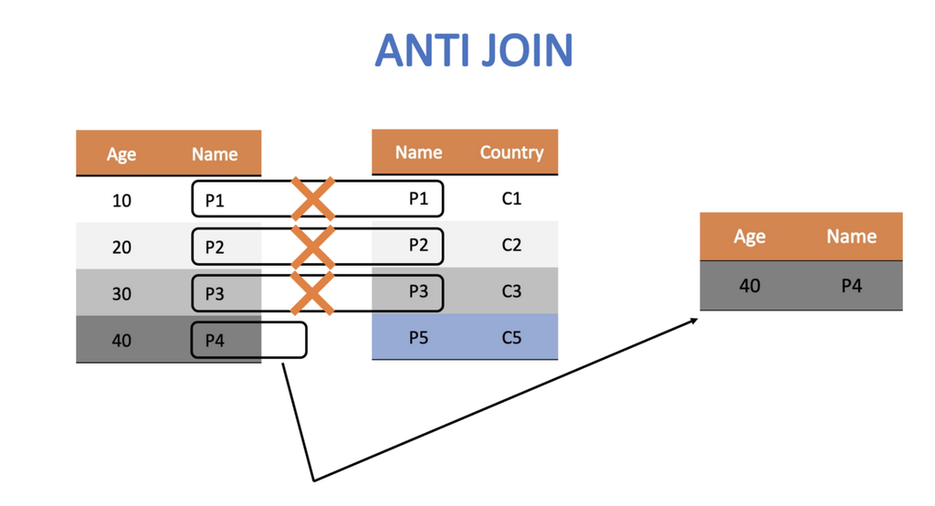

For a good overview of the different `dplyr` joins see here: https://medium.com/the-codehub/beginners-guide-to-using-joins-in-r-682fc9b1f119.

Now let’s remove stop words that don’t help us learn much about what people are saying about the state standards.

```r
ss_tokens_2 <- anti_join(ss_tokens_1,
                           stop_words,
                           by = "word")

head(ss_tokens_2)
```

```
## # A tibble: 6 x 6
##   standards author_id  created_at          conversation_id   id           word
##   <chr>     <chr>      <dttm>              <chr>             <chr>        <chr>
## 1 ccss      1609854356 2021-01-02 00:49:28 1345169706207109… 13451703111… @catt…
## 2 ccss      1609854356 2021-01-02 00:49:28 1345169706207109… 13451703111… hmmmm
## 3 ccss      1609854356 2021-01-02 00:49:28 1345169706207109… 13451703111… common
## 4 ccss      1609854356 2021-01-02 00:49:28 1345169706207109… 13451703111… core
## 5 ccss      1609854356 2021-01-02 00:49:28 1345169706207109… 13451703111… math
## 6 ccss      1609854356 2021-01-02 00:49:28 1345169706207109… 13451703111… makes
```

Notice that we’ve specified the `by =` argument to look for matching words in the `word` column for both data sets and remove any rows from the `tweet_tokens` dataset that match the `stop_words` dataset. Remember when we first tokenized our dataset I conveniently chose `output = word` as the column name because it matches the column name `word` in the `stop_words` dataset contained in the `tidytext` package. This makes our call to `anti_join()`simpler because `anti_join()` knows to look for the column named `word` in each dataset. However this wasn’t really necessary since `word` is the only matching column name in both datasets and it would have matched those columns by default.

#### Your Turn ⤵

Use the code chunk below to take a quick count of the most common tokens in our `ss_tweets_2` data frame to see if the results are a little more meaningful, then answer the questions that follow.

```r
ss_tokens_2 %>%
  count(word, sort = TRUE)
```

```
## # A tibble: 73,596 x 2
##    word          n
##    <chr>     <int>
##  1 common    26665
##  2 core      26470
##  3 math      11788
##  4 #ngsschat  3059
##  5 amp        2904
##  6 #ngss      2655
##  7 students   2559
##  8 science    2300
##  9 standards  2273
## 10 education  2174
## # … with 73,586 more rows
```

#### Your Turn ⤵

1. How many unique tokens are in our data tidied text?
   - 73,596
2. How many times does the word “math” occur in our set of tweets?
   - 11,788

#### Custom Stop Words

Notice that the nonsense word “amp” is among our high frequency words as well as some. We can create our own custom stop word list to to weed out any additional words that don’t carry much meaning but skew our data by being so prominent.

Let’s create a custom stop word list by using the simple `c()` function to combine our words. We can the add a filter to keep rows where words in our `word` column do NOT `!` match words `%in%` `my_stopwords` list:

```r
my_stopwords <- c("amp", "=", "+")

ss_tokens_3 <-
  ss_tokens_2 %>%
  filter(!word %in% my_stopwords)
```

Let’s take a look at our top words again and see if that did the trick:

```r
ss_tokens_3 %>%
  count(word, sort = TRUE)
```

```
## # A tibble: 73,593 x 2
##    word          n
##    <chr>     <int>
##  1 common    26665
##  2 core      26470
##  3 math      11788
##  4 #ngsschat  3059
##  5 #ngss      2655
##  6 students   2559
##  7 science    2300
##  8 standards  2273
##  9 education  2174
## 10 school     2154
## # … with 73,583 more rows
```

Much better! Note that we could extend this stop word list indefinitely. Feel free to use the code chunk below to try adding more words to our stop list.

Before we move any further, let’s save our tidied tweets as a new data frame for Section 3 and also save it as a .csv file in our data folder:

```r
ss_tidy_tweets <- ss_tokens_3

write_csv(ss_tokens_3, here("data", "ss_tidy_tweets.csv"))
```